# An R Package for the Panel Approach Method for Program Evaluation: pampe

Ainhoa Vega-Bayo

Foundations of Economic Analysis II, University of the Basque Country, UPV/EHU

2015-11-10

Abstract

The *pampe* package for R implements the panel data approach method for program evaluation designed to estimate the causal effects of political interventions or treatments. This procedure exploits the dependence among cross-sectional units to construct a counterfactual of the treated unit(s), and it is an appropriate method for research events that occur at an aggregate level like countries or regions and that affect only one or a small number of units. The implementation of the *pampe* package is illustrated using data from Hong Kong and 24 other units, by examining the economic impact of the political and economic integration of Hong Kong with mainland China in 1997 and 2004 respectively.

# An introduction to the panel data approach and program evaluation methods

Program evaluation methodologies have long been used by social scientists to measure the effect of different economic or political interventions (treatments). The problem is, of course, that you cannot observe the outcome both under the intervention and in the absence of the intervention simultaneously, hence the need for program evaluation methods. Traditionally, comparative case studies have been the preferred method by researchers in order to compare units affected by a treatment or event (dubbed the treatment group) to one or more units not affected by this intervention (the control group). The idea is to use the outcome of the control group to obtain an approximation of what would have been the outcome of the treated group had it not been treated. In more recent years, synthetic control methods (Alberto Abadie and Gardeazabal 2003; A. Abadie, Diamond, and Hainmueller 2010) have addressed these issues by introducing a data-driven procedure for selecting the control group. However, the synthetic control methods are not without shortcomings: since the synthetic control is calculated as a convex combination of the units in the donor pool, and thus it does not allow for extrapolation, it might be that a suitable synthetic control for our treated unit does not exist. Furthermore, the synthetic control is designed to be used with explanatory variables or covariates that help explain the variance in the outcome variable. For the cases when the researcher finds that extrapolation is needed to obtain a suitable comparison for the treated unit, or when the covariates available do not properly explain the outcome on which the effect of the treatment is intended to be measured, he or she might prefer to use the panel data approach for program evaluation by (Hsiao, Steve Ching, and Ki Wan 2012). The panel data approach for constructing the counterfactual of the unit subjected to the intervention is to use other units that are not subject to the treatment to predict what would have happened to the treated unit had it not been subject to the policy intervention. The basic idea behind this approach is to rely on the correlations among cross-sectional units. They attribute the cross-sectional dependence to the presence of common factors that drive all the relevant cross-sectional units.

As such, the aim of this article is to present the package [*pampe*](https://CRAN.R-project.org/package=pampe) that implements the panel data approach for program evaluation procedures in R, which is available from the Comprehensive R Archive Network (CRAN) at http://CRAN.R-project.org/package=pampe. The main function in the package is `pampe()`, which computes the counterfactual for the treated unit using the modeling strategy outlined by (Hsiao, Steve Ching, and Ki Wan 2012). The function includes an option to obtain placebo tests. There is an additional function `robustness()`, which conducts a leave-one-out robustness on the results. The data example is also from (Hsiao, Steve Ching, and Ki Wan 2012), which introduced the panel data approach methodology to study the effect of the political and economic integration of Hong Kong with mainland China using other countries geographically and economically close to Hong Kong as possible controls.

The article is organized as follows. The following section is a brief overview of the panel data approach as defined by (Hsiao, Steve Ching, and Ki Wan 2012). The main section of the paper, titled 3, demonstrates the implementation of this method and the use of the *pampe* package with an example, including how to perform inference and robustness checks.

# The panel data approach method for program evaluation

The panel data approach for program evaluation exploits the dependence among cross-sectional units to construct a counterfactual of the treated unit(s), to estimate how the affected unit would have developed in the absence of an intervention. The estimated effect of the policy intervention is therefore simply the difference between the actual observed outcome of the treated unit and this estimated counterfactual. (Hsiao, Steve Ching, and Ki Wan 2012) provide a thorough description of the methodology. Here the focus is on how this method is implemented in the *pampe* package and thus only a brief overview of the procedure is provided.

Let us consider $J+1$ units over $t=1, \ldots, T, \ldots, T'$ periods. Without loss of generality, only the first unit is affected uninterruptedly by an intervention in period $T$ during periods $T, T+1, \ldots, T'$, after an initial pre-intervention period $1, \ldots, T-1$. The left over $J$ units are the controls that form the so-called “donor pool”, and they are not affected by the intervention. Let $Y_{jt}$ denote the outcome variable – the variable for which the intervention effect is being measured – of unit $j$ at period $t$. $Y_{jt}^1$ and $Y_{jt}^0$ denote the outcome of unit $j$ at time $t$ under treatment and in the absence of treatment respectively. We usually do not simultaneously observe both $Y_{jt}^1$ and $Y_{jt}^0$, but instead we observe $Y_{jt}$, which can be written as
$$Y_{jt}=d_{jt}Y_{jt}^1 + (1-d_{jt})
Y_{jt}^0;$$
where $d_{jt}$ is a dummy variable that takes value 1 if unit $j$ is under treatment at time $t$, and value 0 otherwise (Rubin 1974). In this case and without loss of generality, only the first unit is under intervention, so we have that
$$d_{jt}=\left\{\begin{array}{cl}1 & if
j=1 and t\geq T, \\0 & otherwise.\end{array}\right.$$
The treatment or intervention effect for the treated unit can therefore be expressed as
$$\alpha_{1t} = Y_{1t}^1 -
Y_{1t}^0.$$
Of course, we do not observe $Y_{1t}^0$ for $t \geq T$. Thus, the goal of the panel data approach is to obtain an estimate for the effect of the intervention, $\widehat{\alpha}_{1t}$, during the post-treatment period $T, \ldots, T'$ by attempting to replicate the economy of the treated unit in the pre-intervention period $1, \ldots, T-1$; that is, by obtaining an estimate of the outcome variable under no treatment $Y_{1t}^0$. It is assumed that there is no treatment interference between units, i.e., the outcome of the untreated units is not affected by the treatment of the treated unit.

The panel data approach developed by (Hsiao, Steve Ching, and Ki Wan 2012) attempts to predict $Y^0_{1t}$ for $t \geq T$ and therefore to estimate the treatment effect $\alpha_{1t}$ by exploiting the dependency among cross-sectional units in the donor pool and the treated unit, using the following modeling strategy: use $R^2$ (or likelihood values) in order to select the best OLS estimator for $Y^0_{1t}$ using $j$ out of the $J$ units in the donor pool, denoted by $M(j)^*$ for $j=1, \ldots, J$; then choose $M(m)^*$ from $M(1)^*$, …, $M(J)^*$ in terms of a model selection criterion, like AICc, AIC or BIC.[^1]

This strategy is founded on the following underlying model. (Hsiao, Steve Ching, and Ki Wan 2012) assume that $Y^0_{it}$ is generated by a dynamic factor model of the form:

$$\label{eq:hsiaoeq}
Y^0_{jt}=\gamma_j+\mathbf{f}_t\mathbf{b}_j+\varepsilon_{it}, (\#eq:hsiaoeq)$$

where $\gamma_j$ denotes an individual-specific effect, $\mathbf{f}_t$ is a $(1 \times K)$ vector that denotes time varying unobserved common factors, $\mathbf{b}_j$ denotes a $(K \times 1)$ vector of constants that can vary across units, $K$ is the number of common factors, and $\varepsilon_{jt}$ is the time varying idiosyncratic component of individual $j$.

$Y^0_{1t}$ could be predicted using the underlying model (Hsiao, Steve Ching, and Ki Wan 2012) specify and the assumptions they delineate. Instead, they suggest a more practical approach, i.e., using the remaining non-intervened units in the donor pool $Y_{-1t}=(Y_{2t}, \ldots, Y_{Jt})$ to predict $Y_{1t}^0$
$$\label{hsiaoeqmodel}
Y^0_{1t} = \alpha+\beta
Y_{-1t}+\varepsilon_{1t}. (\#eq:hsiaoeqmodel)$$
Note that the panel data approach calculates $OLS$ models of up to $J+1$ parameters; so that if the length of the pre-treatment period $t=1, 2, \ldots, T'-1$ is not of a much higher order than that, the regressions $M(J-1)^*, M(J)^*$ cannot be calculated because there are not enough degrees of freedom. To avoid this problem, we propose the following slight modification to the previously outlined modeling strategy: use $R^2$ in order to select the best OLS estimator for $Y^0_{1t}$ using $j$ out of the $J$ units in the donor pool, denoted by $M(j)^*$ for $j=1, \ldots, T_0-4$; then choose $M(m)^*$ from $M(1)^*$, …, $M(T_0-4)^*$ in terms of a model selection criterion (in our case AICc). Note that the key difference is that while we allowed models up to $M(J)^*$, this is now modified to allow models up to $M(T_0-4)^*$, with $T_0-4<J$.[^2]

To implement the method, the *pampe* package relies on the use of the `regsubsets()` function from the [*leaps*](https://CRAN.R-project.org/package=leaps) package by (Lumley 2014). The main user-available function of the *pampe* package, also called `pampe()`, calculates all OLS models for $Y^0_{1t}$ as dependent variable and using $j$ out of the $J$ units in the donor pool as explanatory variables, denoted by $M(j)^*$ for $j=1, \ldots, J$ or up to order $J'<J$ if specified by the user, which would override the default outlined above; then the best one is kept in terms of a model selection criterion ($AIC$, $AICc$, or $BIC$) also specified by the user.

In order to perform inference on the results obtained, the package implements the so-called placebo studies procedure outlined in (Alberto Abadie and Gardeazabal 2003; A. Abadie, Diamond, and Hainmueller 2010) and (Alberto Abadie, Diamond, and Hainmueller 2015).[^3] The basic idea behind the placebo studies is to iterate the application of the panel data approach by reassigning the treatment to other non-treated units, i.e., to the controls in the donor pool; or by reassigning the treatment to other pre-intervention periods, when the treatment had yet to occur. The set of placebo effects can therefore be compared to the effect that was estimated for the “real” time and unit, in order to evaluate whether the effect estimated by the panel data approach when and where the treatment actually occurred is large relative to the placebo effects.

# Implementing *pampe* in R

This section expands on the implementation of the method itself as well as the placebo studies and how they can be interpreted by the user by means of two examples: the political and economic integration of Hong Kong with mainland China in 1997 and 2004, plus the reassignation of the treatment to other units in the control group and different pre-treatment dates. (Hsiao, Steve Ching, and Ki Wan 2012) use a combination of other countries to construct a counterfactual for Hong Kong that resembled the economy prior to the political and economic integration. The `growth` dataset, obtained from the supplemental materials of (Hsiao, Steve Ching, and Ki Wan 2012) contains information on the quarterly real GDP growth rate of 24 countries (the donor pool) and Hong Kong from 1993 Q1 to 2008 Q1, computed as the change with respect to the same quarter in the previous year.

```r
> library("pampe")
> data("growth")
```

The data is organized in standard cross-sectional data format, with the variables (the quarterly real GDP growth rate of the countries in the donor pool act as explanatory variables) extending across the columns and the quarters (time-periods) extending across rows. It is important for the user to have his or her data in this standard format to correctly apply the methodology. Naming the rows and especially the columns is also strongly recommended though not required.

If the user does not have the data in standard wide format, the `pampe` package also includes an optional `pampeData` function that prepares the data according to the required format. It also helps reshape the data in case the user has it in long format. This function should be run prior to the `pampe` function. For example, if we had a dataset in long format such as the `Produc` dataset from the `plm` package:

```r
> library("plm")
> data(Produc, package = "plm")
> long.data <- plm.data(Produc)
> head(long.data)
```

```r
    state year     pcap     hwy   water    util       pc   gsp    emp unemp
1 ALABAMA 1970 15032.67 7325.80 1655.68 6051.20 35793.80 28418 1010.5   4.7
2 ALABAMA 1971 15501.94 7525.94 1721.02 6254.98 37299.91 29375 1021.9   5.2
3 ALABAMA 1972 15972.41 7765.42 1764.75 6442.23 38670.30 31303 1072.3   4.7
4 ALABAMA 1973 16406.26 7907.66 1742.41 6756.19 40084.01 33430 1135.5   3.9
5 ALABAMA 1974 16762.67 8025.52 1734.85 7002.29 42057.31 33749 1169.8   5.5
6 ALABAMA 1975 17316.26 8158.23 1752.27 7405.76 43971.71 33604 1155.4   7.7
```

Note that `"year"` is the name of the time index and `"state"` is the id index, and that there is data on eight variables. If we want to keep data on the variable "pcap" and transform that into a wide format, in which `"year"` spans across rows and `"state"` across columns, we can use the following call to `pampeData` for that.

```r
> wide.data <- pampeData(long.data, start = 1970, frequency = 1,
+                        timevar = "year", idvar = "state", "yvar" = "pcap")
> wide.data[1:5, 1:5]
```

```r
      ALABAMA  ARIZONA ARKANSAS CALIFORNIA COLORADO
1970 15032.67 10148.42  7613.26   128545.4 11402.52
1971 15501.94 10560.54  7982.03   132263.3 11682.06
1972 15972.41 10977.53  8309.01   134451.5 12010.91
1973 16406.26 11598.26  8399.59   135988.4 12473.28
1974 16762.67 12129.06  8512.05   136827.3 12964.14
```

Of course, the data above is for the `"pcap"` variable.

Having introduced the optional data preparation, let us now continue with the main function and example of this paper, the `growth` dataset and the `pampe` function. Observe how the `wide.data` above is in an equivalent format as the `growth` data below after having applied the `pampeData` function.

```r
> growth[1:10, 1:5]
```

```r
       HongKong   Australia      Austria     Canada      Denmark
1993Q1    0.062 0.040489125 -0.013083510 0.01006395 -0.012291821
1993Q2    0.059 0.037856919 -0.007580798 0.02126387 -0.003092842
1993Q3    0.058 0.022509481  0.000542671 0.01891943 -0.007764421
1993Q4    0.062 0.028746550  0.001180751 0.02531683 -0.004048589
1994Q1    0.079 0.033990391  0.025510849 0.04356715  0.031094401
1994Q2    0.068 0.037919372  0.019941313 0.05022538  0.064280003
1994Q3    0.046 0.052289413  0.017087875 0.06512183  0.045955455
1994Q4    0.052 0.031070896  0.023035197 0.06733068  0.055166411
1995Q1    0.037 0.008696091  0.025292696 0.05092120  0.048057177
1995Q2    0.029 0.006773674  0.021849955 0.03152506  0.011953605
```

In this example, the treated unit – Hong Kong – is in the first column, while the 24 non-treated units are in columns 2 to 25; and the time-periods (quarters) are in rows. Note how both the rows and the columns are named for ease of use and interpretation.

## Using the function `pampe()`

Once the data is in the correct format, it is just a matter of applying the `pampe()` command to the dataset. Note that it requires a balanced dataset, i.e., no missing values are allowed.[^4] As the bare minimum, the command requires the arguments specified in Table 1.

Table 1: Necessary arguments for the `pampe` function.

[output not shown]

No additional arguments are necessary, though one may choose to pass other arguments as well. Setting the `controls` argument is especially recommended, otherwise the default is to use all the remaining (non-treated) columns in the dataset as controls. For example, let us run the `pampe()` functions using only the bare-bones arguments for the economic integration of Hong Kong as carried out by (Hsiao, Steve Ching, and Ki Wan 2012). We first set the pre-treatment and treatment periods; the economic integration of Hong Kong happened in 2004Q1. The pre-treatment period therefore ranges from 1993Q1 to 2003Q4, and the treatment and post-treatment goes from 2004Q1 to 2008Q1. It is useful to define the periods objects before calling the function so that you can use them later when processing the results, although inputting them directly into the function call is of course an option.

```r
> time.pretr <- c("1993Q1", "2003Q4")
> time.tr <- c("2004Q1", "2008Q1")
> ## Or if you know the row indexes use those directly, e.g.
> time.tr <- 45:61
> ## The treated unit
> treated <- "HongKong"
> ## Call the function with the bare minimum arguments specified
> econ.integ <- pampe(time.pretr = time.pretr, time.tr = time.tr,
+                     treated = treated, data = growth)
```

Notice that the defaults, which are used in this case, are to use all the controls and the AICc criterion. You can print out a summary of the optimal model:

```r
> summary(econ.integ$model)

Call:
lm(formula = fmla, data = data[time.pretr, ])

Residuals:
      Min        1Q    Median        3Q       Max
-0.016264 -0.008368 -0.001369  0.008332  0.031529

Coefficients:
             Estimate Std. Error t value Pr(>|t|)
(Intercept) -0.001940   0.003703  -0.524  0.60339
Austria     -1.011560   0.168235  -6.013 6.03e-07 ***
Italy       -0.317654   0.159060  -1.997  0.05321 .
Korea        0.344735   0.046899   7.351 9.72e-09 ***
Mexico       0.312858   0.051008   6.134 4.14e-07 ***
Norway       0.322183   0.053776   5.991 6.45e-07 ***
Singapore    0.184509   0.054569   3.381  0.00172 **
---
Signif. codes:  0 '***' 0.001 '**' 0.01 '*' 0.05 '.' 0.1 ' ' 1

Residual standard error: 0.0117 on 37 degrees of freedom
Multiple R-squared:  0.931,  Adjusted R-squared:  0.9198
F-statistic: 83.16 on 6 and 37 DF,  p-value: < 2.2e-16
```

This replicates the results obtained by (Hsiao, Steve Ching, and Ki Wan 2012) for the economic integration of Hong Kong using all 24 units as the possible controls, and the $AICc$ selection criterion. That is, the counterfactual for Hong Kong is built as a combination of Austria, Italy, Korea, Mexico, Norway, and Singapore; i.e., those are the countries that best replicate the economy of Hong Kong in the period prior to the economic integration, according to the model by (Hsiao, Steve Ching, and Ki Wan 2012).

If one wishes to fine-tune the process, the arguments specified in Table 2 can be passed to the function as well.[^5]

Table 2: Other non-required arguments for the `pampe` function.

[output not shown]

For example, let us now try to replicate the results obtained by (Hsiao, Steve Ching, and Ki Wan 2012) for the political integration of Hong Kong using the $AICc$ criterion. If one were not to specify the set of possible controls as they do, the function would aimt to use all controls. Since those are too many given the pre-treatment period and the user has not specified a custom `nvmax`, the default `nvmax` setting would switch to the length of the pre-treatment period minus four to allow for at least three degrees of freedom.

The treated unit remains the same, but the pre-treatment and treatments are different. If we call the function with the AICc criterion, and use the default (`"All"`) for the controls:

```r
> treated <- "HongKong"
> time.pretr <- 1:18  # 1993Q1-1997Q2
> time.tr <- 19:44 # 1997Q3-2003Q4
> pol.integ.all <- pampe(time.pretr = time.pretr, time.tr = time.tr,
+                        treated = treated, data = growth, select = "AICc")
```

We will obtain the following results:

```r
Call:
lm(formula = fmla, data = data[time.pretr, ])

Residuals:
       Min         1Q     Median         3Q        Max
-1.330e-03 -3.293e-04  9.270e-06  1.610e-04  1.621e-03

Coefficients:
               Estimate Std. Error t value Pr(>|t|)
(Intercept)    0.121549   0.003623  33.552 6.80e-10 ***
Canada         0.448293   0.027020  16.591 1.76e-07 ***
Germany        0.193300   0.040933   4.722  0.00150 **
Italy          0.657226   0.069384   9.472 1.27e-05 ***
Japan         -0.923212   0.038457 -24.007 9.66e-09 ***
Korea         -1.022964   0.040920 -24.999 7.01e-09 ***
UnitedKingdom  0.856127   0.054689  15.654 2.77e-07 ***
Philippines   -0.849836   0.042193 -20.142 3.85e-08 ***
Indonesia     -0.118165   0.016813  -7.028  0.00011 ***
Thailand       0.221161   0.021389  10.340 6.61e-06 ***
---
Signif. codes:  0 '***' 0.001 '**' 0.01 '*' 0.05 '.' 0.1 ' ' 1

Residual standard error: 0.001186 on 8 degrees of freedom
Multiple R-squared:  0.9982,  Adjusted R-squared:  0.9962
F-statistic: 498.3 on 9 and 8 DF,  p-value: 5.029e-10
```

That is, the call does not throw out an error because of the slightly modified modeling strategy specified in the previous section, but this does not replicate the results obtained by (Hsiao, Steve Ching, and Ki Wan 2012) and might not be what the user wants.

In this case, to replicate their results, the set of possible controls has to be specified first, and then we call the function:

```r
> possible.ctrls <- c("China", "Indonesia", "Japan", "Korea", "Malaysia",
+                     "Philippines", "Singapore", "Taiwan", "UnitedStates", "Thailand")
> pol.integ <- pampe(time.pretr = time.pretr, time.tr = time.tr, treated = treated,
+                    controls = possible.ctrls, data = growth)
```

```r
Call:
lm(formula = fmla, data = data[time.pretr, ])

Residuals:
      Min        1Q    Median        3Q       Max
-0.007304 -0.004851  0.001140  0.004367  0.007178

Coefficients:
             Estimate Std. Error t value Pr(>|t|)
(Intercept)   0.02630    0.01705   1.543   0.1469
Japan        -0.67596    0.11169  -6.052 4.08e-05 ***
Korea        -0.43230    0.06338  -6.821 1.22e-05 ***
UnitedStates  0.48603    0.21952   2.214   0.0453 *
Taiwan        0.79259    0.30989   2.558   0.0238 *
---
Signif. codes:  0 '***' 0.001 '**' 0.01 '*' 0.05 '.' 0.1 ' ' 1

Residual standard error: 0.005775 on 13 degrees of freedom
Multiple R-squared:  0.9314,  Adjusted R-squared:  0.9103
F-statistic: 44.15 on 4 and 13 DF,  p-value: 1.919e-07
```

If the user wants to replicate their results with AIC:

```r
> pol.integ.aic <- pampe(time.pretr = time.pretr, time.tr = time.tr,
+                        treated = treated, controls = possible.ctrls,
+                        data = growth, select = "AIC")
```

```r
Call:
lm(formula = fmla, data = data[time.pretr, ])

Residuals:
       Min         1Q     Median         3Q        Max
-0.0068954 -0.0030066  0.0009741  0.0024680  0.0078690

Coefficients:
             Estimate Std. Error t value Pr(>|t|)
(Intercept)   0.03161    0.01639   1.928 0.077815 .
Japan        -0.69002    0.10560  -6.534 2.79e-05 ***
Korea        -0.37668    0.06884  -5.472 0.000143 ***
UnitedStates  0.80994    0.28729   2.819 0.015480 *
Philippines  -0.16237    0.09993  -1.625 0.130163
Taiwan        0.61889    0.31097   1.990 0.069850 .
---
Signif. codes:  0 '***' 0.001 '**' 0.01 '*' 0.05 '.' 0.1 ' ' 1

Residual standard error: 0.005442 on 12 degrees of freedom
Multiple R-squared:  0.9438,  Adjusted R-squared:  0.9204
F-statistic:  40.3 on 5 and 12 DF,  p-value: 4.291e-07
```

Thus, the user can play around with the `controls`, `nbest`, `nvmax` and `select` arguments such that they better suit their needs and their particular dataset. As the bare minimum, `time.pretr`, `time.tr`, `treated` and `data` are required for the function to run.

## Obtaining and transmitting results

Once the function has been correctly run and the user is satisfied with the model, the next step is to process the results obtained. The `pampe()` function returns an object of class ‘`pampe`’ with the objects specified in Table 3.[^6]

Table 3: Results given by the `pampe` function.

| `controls` | A named vector of the controls finally included in the model. |
| --- | --- |
| `model` | An object of class ‘`lm`’ with the optimal model. Usual methods such as `fitted()`, `residuals()`, `summary()`, etc. can be used on it. |
| `counterfactual` | A named matrix of the actual path together with the path of the estimated counterfactual for the `time.pretr` and `time.tr` periods. |
| `data` | The data used for the estimation, stored for later use in, for example, the `robustness` function also included in the package, which is explained later on. |

Continuing with the example of the political integration of Hong Kong with the $AICc$ criterion and the set of possible controls as specified by (Hsiao, Steve Ching, and Ki Wan 2012):

```r
> ## Setup
> treated <- "HongKong"
> time.pretr <- 1:18  # 1993Q1-1997Q2
> time.tr <- 19:44 # 1997Q3-2003Q4
> possible.ctrls <- c("China", "Indonesia", "Japan", "Korea", "Malaysia",
+                     "Philippines", "Singapore", "Taiwan", "UnitedStates", "Thailand")
> ## Call the function with AICc and the possible controls
> pol.integ <- pampe(time.pretr = time.pretr, time.tr = time.tr, treated = treated,
+                    controls = possible.ctrls, data = growth)
```

```r
Call:
lm(formula = fmla, data = data[time.pretr, ])

Residuals:
      Min        1Q    Median        3Q       Max
-0.007304 -0.004851  0.001140  0.004367  0.007178

Coefficients:
             Estimate Std. Error t value Pr(>|t|)
(Intercept)   0.02630    0.01705   1.543   0.1469
Japan        -0.67596    0.11169  -6.052 4.08e-05 ***
Korea        -0.43230    0.06338  -6.821 1.22e-05 ***
UnitedStates  0.48603    0.21952   2.214   0.0453 *
Taiwan        0.79259    0.30989   2.558   0.0238 *
---
Signif. codes:  0 '***' 0.001 '**' 0.01 '*' 0.05 '.' 0.1 ' ' 1

Residual standard error: 0.005775 on 13 degrees of freedom
Multiple R-squared:  0.9314,  Adjusted R-squared:  0.9103
F-statistic: 44.15 on 4 and 13 DF,  p-value: 1.919e-07
```

Let us check the additional results:

```r
> pol.integ
```

```r
$controls
[1] "Japan"        "Korea"        "UnitedStates" "Taiwan"

$model
Call:
lm(formula = fmla, data = data[time.pretr, ])
Coefficients:
 (Intercept)         Japan         Korea  UnitedStates        Taiwan
      0.0263       -0.6760       -0.4323        0.4860        0.7926

$counterfactual
     1993Q1      1993Q2      1993Q3      1993Q4      1994Q1      1994Q2
 0.05499950  0.06083154  0.06502118  0.06102413  0.07395480  0.06554503
     1994Q3      1994Q4      1995Q1      1995Q2      1995Q3      1995Q4
...

 $data
 ...
```

A `summary()` method is included for objects of class ‘`pampe`’, with useful information for the researcher:

```r
> summary(pol.integ)
```

```r
Selected controls:
 Japan, Korea, UnitedStates, and Taiwan.

Time-average estimated treatment effect:
 -0.0396291

Optimal model estimation results:

              Estimate Std. Error t value  Pr(>|t|)
(Intercept)   0.026300   0.017048  1.5427   0.14689
Japan        -0.675964   0.111688 -6.0522 4.084e-05 ***
Korea        -0.432298   0.063377 -6.8211 1.223e-05 ***
UnitedStates  0.486032   0.219521  2.2141   0.04531 *
Taiwan        0.792593   0.309892  2.5576   0.02385 *
---
Signif. codes:  0 '***' 0.001 '**' 0.01 '*' 0.05 '.' 0.1 ' ' 1

Residual standard error: 0.0058 on 13 degrees of freedom
Multiple R-squared: 0.931,     Adjusted R-squared: 0.91
F-statistic: 44.15 on 4 and 13 DF, p-value: 1.919427e-07
```

Although not directly printed, the `summary()` method for objects of class ‘`pampe`’ also includes the actual and counterfactual paths which can be accessed via `summary(pol.integ)$res.table`. We can also manipulate `pol.integ$model` as we wish with the usual methods since it is an object of class ‘`lm`’. For example, `summary(pol.integ$model)` can be used to obtain a summary, `residuals(pol.integ$model)` for the residuals, or `fitted(pol.integ$model)` to recover the estimated values.

Another method included in the package is `plot()`. It works on objects of class ‘`pampe`’ to produce a plot of the actual evaluation of the treated unit together with the predicted counterfactual path. A simple plot call to our saved ‘`pampe`’ object, `plot(pol.integ)`, would produce Figure 1.

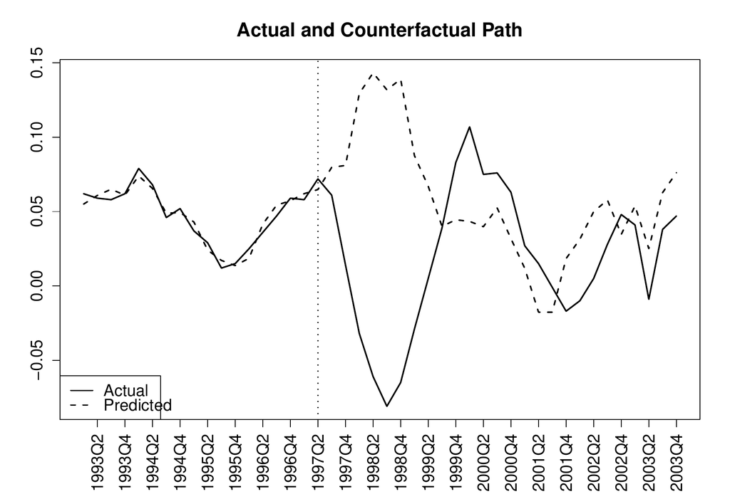

Figure 1: Output of `plot(pol.integ)`.

If, however, we want to produce and manipulate our own plot, it is just a matter of running a `matplot()` of the actual value together with the counterfactual saved in the results of the function (see Figure 2):

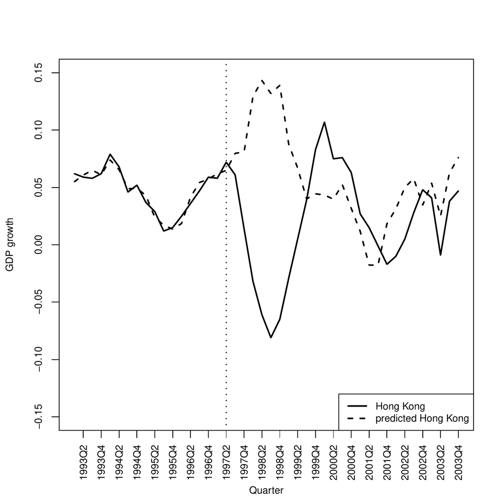

Figure 2: Output of using `matplot()`.

```r
> ## A plot of the actual Hong Kong together with the predicted path
> matplot(c(time.pretr, time.tr), pol.integ$counterfactual, type = "l", xlab = "",
+         ylab = "GDP growth", ylim = c(-0.15, 0 .15), col = 1, lwd = 2, xaxt = "n")
> ## Axis labels & titles
> axis(1, at = c(time.pretr, time.tr)[c(seq(2, length(c(time.pretr, time.tr)),
+      by = 2))], labels = c(rownames(growth)[c(time.pretr, time.tr)
+      [c(seq(2, length(c(time.pretr, time.tr)), by = 2))]]), las = 3)
> title(xlab = "Quarter", mgp = c(3.6, 0.5, 0))
> ## Legend
> legend("bottomright", c("Hong Kong", "predicted Hong Kong"),
+        col = 1, lty = c(1, 2), lwd = 2)
> ## Add a vertical line when the tr starts
> abline(v = time.pretr[length(time.pretr)], lty = 3, lwd = 2)
```

To obtain a plot of the estimated treatment effect, we first calculate the treatment effect, which is the difference between the actual and predicted (counterfactual) path; then we plot it (see Figure 3). Note that if the method works well to replicate the economy in the pre-treatment period, the treatment effect should be around zero in the pre-treatment period.

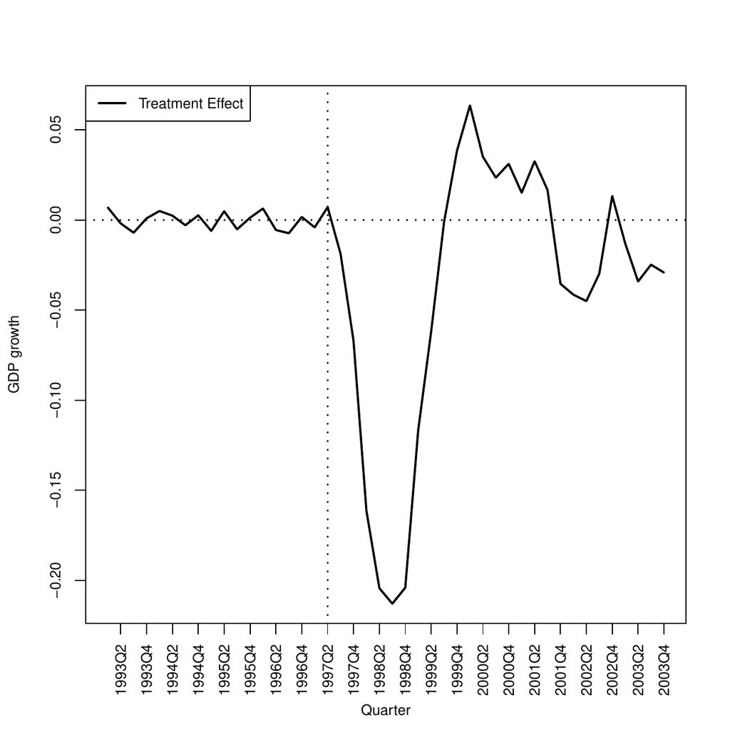

Figure 3: Plot of the estimated treatment effect.

```r
> tr.effect <- pol.integ$counterfactual[, 1] - pol.integ$counterfactual[, 2]
> ## A plot of the estimated treatment effect
> plot(c(time.pretr, time.tr), tr.effect, type = "l", ylab = "GDP growth",
+      xlab = "", col = 1, lwd = 2, xaxt = "n")
> ## Axis labels & titles
> axis(1, at = c(time.pretr, time.tr)[c(seq(2, length(c(time.pretr, time.tr)),
+      by = 2))], labels = c(rownames(growth)[c(time.pretr, time.tr)
+      [c(seq(2, length(c(time.pretr, time.tr)), by = 2))]]), las = 3)
> title(xlab = "Quarter", mgp = c(3.6, 0.5, 0))
> ## Legend
> legend("topleft", "Treatment Effect", col = 1, lty = 1, lwd = 2)
> ## Add a vertical line when the treatment starts
> abline(v = time.pretr[length(time.pretr)], lty = 3, lwd = 2)
> ## Horizontal line on zero
> abline(h = 0, lty = 3, lwd = 2)
```

The user might also be interested in exporting tables that show the results of the procedure, to be used in a LaTeX document. Simply manipulating the data and using `xtable` from the package of the same name [*xtable*](https://CRAN.R-project.org/package=xtable) (Dahl 2014) one can obtain the tables shown in (Hsiao, Steve Ching, and Ki Wan 2012). An `xtable` method is also included for this purpose, which requires the output of the ‘`pampe`’ object and the user specifying which table type he or she wants: the table of the model or the treatment table, which includes the actual, predicted, and treatment paths.

```r
> library("xtable")
> xtable(pol.integ, ttype = "model")
> xtable(pol.integ, ttype = "treatment")
```

## Placebo tests

In order to perform inference on the results obtained, the package implements the so-called placebo studies procedure outlined in (Alberto Abadie and Gardeazabal 2003; A. Abadie, Diamond, and Hainmueller 2010) and (Alberto Abadie, Diamond, and Hainmueller 2015). The idea is to iterate the application of the panel data approach by reassigning the treatment to other non-treated units, i.e., to the controls in the donor pool; or by reassigning the treatment to other pre-intervention periods, when the treatment had yet to occur. The set of placebo effects can therefore be compared to the effect that was estimated for the “real” time and unit, in order to evaluate whether the effect estimated by the panel data approach when and where the treatment actually occurred is large relative to the placebo effects.

The function `pampe()` has both placebo studies (placebo-controls and placebos-in-time) built in. Thus the user can obtain the results from the placebo studies and perform this type of statistical inference simply by switching the last argument of the function `pampe()`, `placebos`, from the default `FALSE` to either `"controls"`, `"time"`, or `"Both"`. Continuing the previous example, the call to the function is identical to the `pol.integ` one except that now we also ask for the placebos. The other arguments are inherited from before.

```r
> pol.integ.placebos <- pampe(time.pretr = time.pretr, time.tr = time.tr,
+                             treated = treated, controls = possible.ctrls,
+                             data = growth, placebos = "Both")
```

Now the results obtained, besides `pol.integ.placebos$controls`, `$model`, and `$counterfactual` like before, include the ones in Table 4.

Table 4: Additional results from the `pampe` function.

[output not shown]

For example, if we take a look at the first five rows and columns of `pol.integ.placebos$` `placebo.time$tr.effect`:

```r
             1997Q3        1995Q3        1995Q4        1996Q1        1996Q2
1993Q1  0.007000500 -0.0084630055  0.0005825015  0.0005170915  3.642217e-05
1993Q2 -0.001831535  0.0046961110  0.0036438429  0.0009914089 -6.703595e-04
1993Q3 -0.007021179  0.0005439412 -0.0035785257 -0.0003308651 -2.804963e-03
1993Q4  0.000975869 -0.0065735180 -0.0041505788 -0.0021485760  3.376669e-03
1994Q1  0.005045203  0.0081985975  0.0036386090  0.0003446360  1.552006e-04
```

We can see that it is a table with the estimated treatment effects (difference between actual and predicted); the first column shows the actual treatment effect, whereas in the remaining columns we have the estimated treatment effect after having reassigned the treatment to other periods, specified in the column name. In this case, the second column has the treatment reassigned to 1995Q3.

Now these additional results can be used for plots and to check whether the treatment effect is significant. When the saved ‘`pampe`’ object has placebo studies stored inside, a `plot()` call to the ‘`pampe`’ object will produce the placebo plot(s) as well as the initial actual/predicted path plot. The placebo plot for the control reassignment is given in Figure 4.

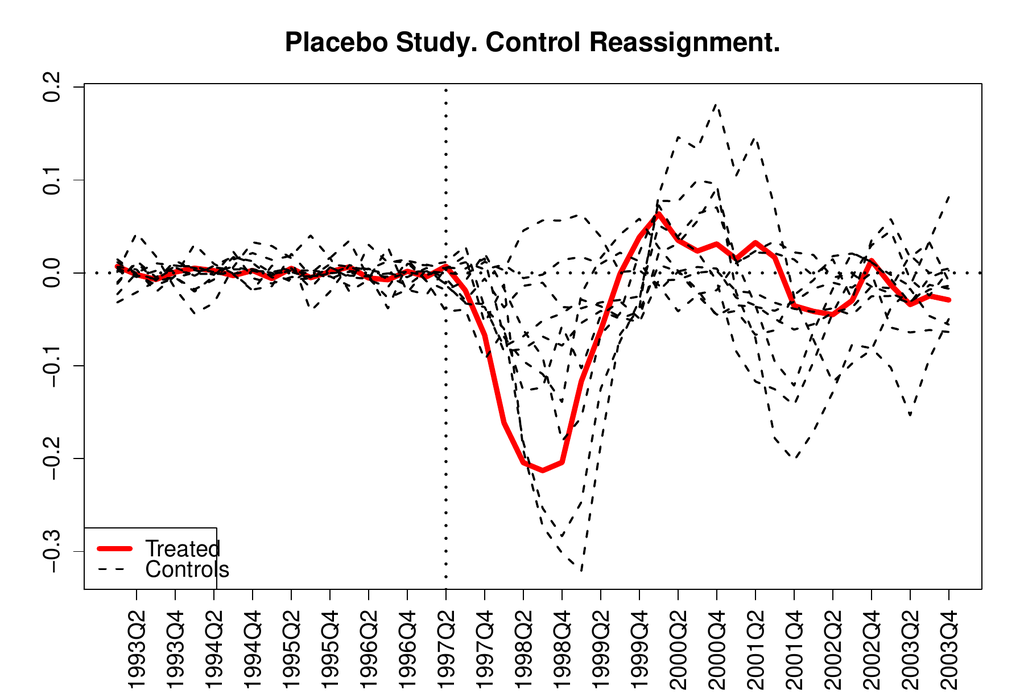

Figure 4: Placebo plot.

Or again, the user might want to produce their own plot to adapt it to their required style:

```r
> mspe <- pol.integ.placebos$placebo.ctrl$mspe
> linewidth  <- matrix(2, 1, ncol(mspe) - 1)
> linewidth <- append(linewidth, 5, after = 0)
>
> matplot(c(time.pretr, time.tr), pol.integ.placebos$placebo.ctrl$tr.effect,
+         type = "l", xlab = "", ylab = "GDP growth gap",
+         col = c("red", matrix(1, 1, ncol(mspe) - 1)),
+         lty = c(1, matrix(2, 1, ncol(mspe) - 1)), lwd = linewidth,
+         ylim = c(-0.35, 0.2), xaxt = "n")
> ## Axis
> axis(1, at = c(time.pretr, time.tr)[c(seq(2, length(c(time.pretr, time.tr)),
+      by = 2))], labels = c(rownames(growth)[c(time.pretr, time.tr)
+      [c(seq(2, length(c(time.pretr, time.tr)), by = 2))]]), las = 3)
> title(xlab = "Quarter", mgp = c(3.6, 0.5, 0))
> ## Legend
> legend("bottomleft", c("Hong Kong", "Controls"), col = c("red", 1),
+        lty = c(1, 2), lwd = c(5, 2))
> ## Horizontal & vertical lines
> abline(h = 0, lty = 3, lwd = 2)
> abline(v = time.pretr[length(time.pretr)], lty = 3, lwd = 2)
```

As an example of what a significant treatment effect would look like, we carry out the treatment-reassignment placebo tests for the economic integration of Hong Kong, which (Hsiao, Steve Ching, and Ki Wan 2012) find to be significant.

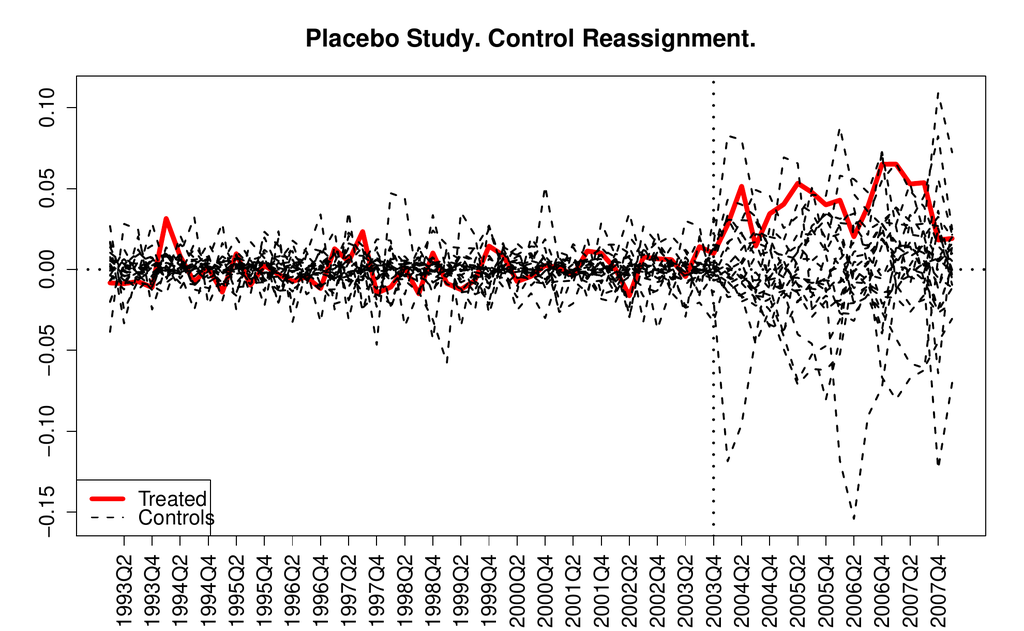

Figure 5: Placebo plot with control reassignment.

```r
> time.pretr <- c("1993Q1", "2003Q4")
> time.tr <- c("2004Q1", "2008Q1")
> ## Or if you know the row indexes use those directly, e.g.
> time.tr <- 45:61
> ## The treated unit
> treated <- "HongKong"
> econ.integ.placebos <- pampe(time.pretr = time.pretr, time.tr = time.tr,
+                              treated = treated, data = growth,
+                              placebos = "controls")
> plot(econ.integ.placebos)
```

Let us now check the results obtained from the placebos-in-time. This tests for the causal nature of the effect. If by reassigning the treatment to a previous period we observe that the estimated path (in the pre-treatment period) does not appear to have an effect, but there is still an effect in the actual treatment, then one can assume that the estimated effect is indeed caused by the treatment (though in this case it turns out to be non-significant).

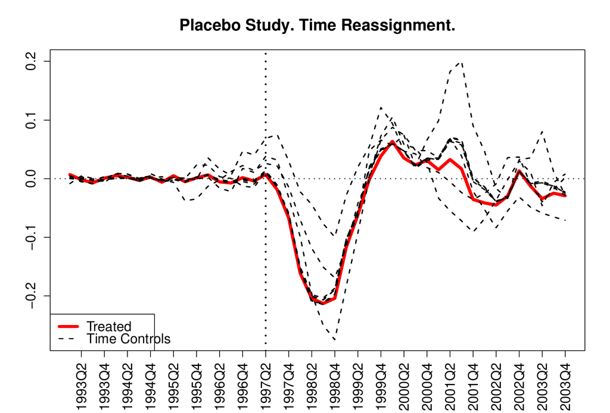

Figure 6: Placebo plot with time reassignment.

Or the user can produce his or her own plot:

```r
> ## Plot of the placebos-in-time
> ## For example let's plot the first time reassignment, to 1995Q3
> ## (2nd column)
> placebo.in.time1 <- pol.integ.placebos$placebo.time$tr.effect[, 2] +
+                     growth[c(time.pretr, time.tr), 1]
> matplot(c(time.pretr, time.tr), cbind(growth[c(time.pretr, time.tr), 1],
+         pol.integ.placebos$counterfactual, placebo.in.time1), type = "l",
+         ylab = "GDP growth", xlab = "", ylim = c(-0.25, 0.2), col = 1,
+         lwd = 3, xaxt = "n")
> ## Axis
> axis(1, at = c(time.pretr, time.tr)[c(seq(2, length(c(time.pretr, time.tr)),
+      by = 2))], labels = c(rownames(growth)[c(time.pretr, time.tr)
+      [c(seq(2, length(c(time.pretr, time.tr)), by = 2))]]), las = 3)
> title(xlab = "Quarter", mgp = c(3.6, 0.5, 0))
> ## Legend
> legend("bottomleft", c("actual", "predicted", paste("placebo",
+        colnames(pol.integ.placebos$placebo.time$tr.effect)[2], sep = " ")),
+        col = 1, lty = c(1, 2, 3), lwd = 3)
> ## Two vertical lines
> abline(v = time.pretr[length(time.pretr)], lty = 2, lwd = 3)
> abline(v = which(colnames(pol.integ.placebos$placebo.time$tr.effect)[2]
+        == rownames(growth)), lty = 3, lwd = 3)
> ## We can also plot the gaps all at the same time
> mspe <- pol.integ.placebos$placebo.time$mspe
> linewidth  <- matrix(2, 1, ncol(mspe) - 1)
> linewidth <- append(linewidth, 5, after = 0)
>
> matplot(c(time.pretr, time.tr), pol.integ.placebos$placebo.time$tr.effect,
+         type = "l", xlab = "", ylab = "GDP growth gap",
+         col = c("red", matrix(1, 1, ncol(mspe) - 1)),
+         lty = c(1, matrix(2, 1, ncol(mspe) - 1)), lwd = linewidth,
+         ylim = c(-0.35, 0.2), xaxt = "n")
> ## Axis
> axis(1, at = c(time.pretr, time.tr)[c(seq(2, length(c(time.pretr, time.tr)),
+      by = 2))], labels = c(rownames(growth)[c(time.pretr, time.tr)
+      [c(seq(2, length(c(time.pretr, time.tr)), by = 2))]]), las = 3)
> title(xlab = "Quarter", mgp = c(3.6, 0.5, 0))
> ## Legend
> legend("topleft", c("Hong Kong", "Controls"), col = c("red", 1),
+        lty = c(1, 2), lwd = c(5, 2))
> ## Horizontal line
> abline(h = 0, lty = 3, lwd = 2)
```

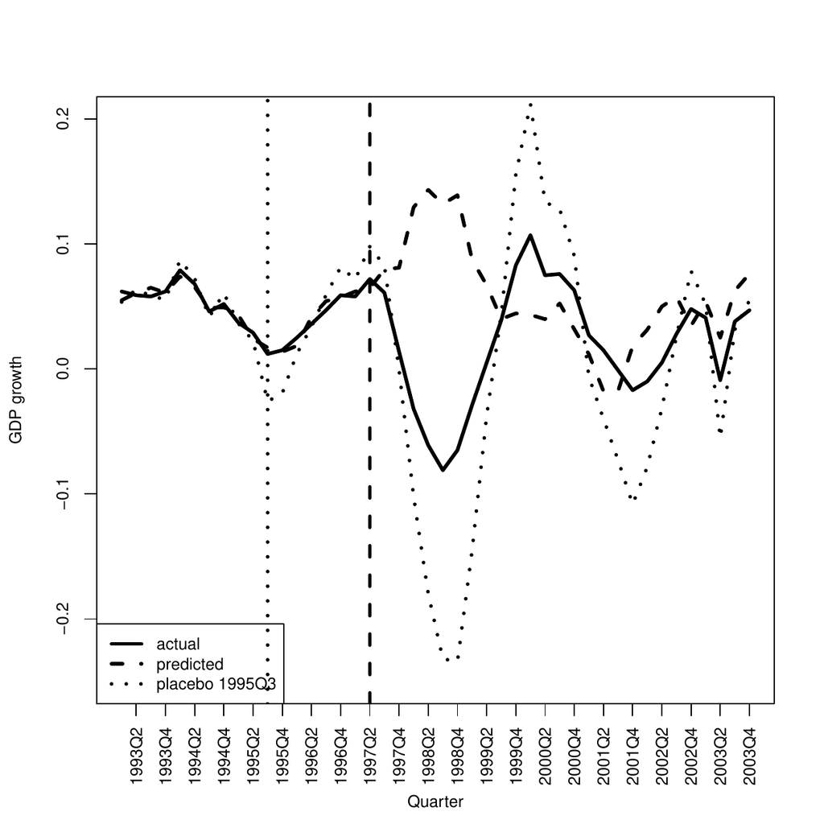

Figure 7: Plot of the placebos-in-time.

## Robustness checks

Besides placebo studies for inference tests, (Alberto Abadie, Diamond, and Hainmueller 2015) show the importance of running robustness checks on the results obtained. This section demonstrates how to implement the so-called leave-one-out robustness check, which iteratively removes one of the units in the control group of the final model, to check whether the results are driven by one unit in particular or, in contrast, the results are robust to removing one unit.

The leave-one-out robustness check can be applied using the other user-available function included in the package, `robustness()`. After applying the initial function `pampe()`, the user can carry out the robustness check simply by calling the function `robustness()` and specifying the name of the saved object from the `pampe` call.

```r
> rob.check <- robustness(pol.integ)
```

This produces a matrix with the actual path, the initial predicted path, and each leave-one-out predicted path. Its first five rows are given by:

```r
       Actual Predict w/ all   w/o Japan  w/o Korea w/o UnitedStates w/o Taiwan
1993Q1  0.062     0.05499950  0.05993785 0.04167956      0.058347659 0.05173061
1993Q2  0.059     0.06083154  0.05414176 0.05082512      0.064482544 0.05973967
1993Q3  0.058     0.06502118  0.05208924 0.05861153      0.068493568 0.06459402
1993Q4  0.062     0.06102413  0.05398689 0.05587109      0.063964428 0.05918035
1994Q1  0.079     0.07395480  0.05629484 0.07740008      0.071861773 0.07673810
```

The user can then plot this robustness check by calling the `plot()` method to the saved object. `xtable` and `summary` methods are also provided.

```r
plot(rob.check)
```

The following plot (Figure 8) shows that the results obtained with four countries (Japan, Korea, US and Taiwan) are robust to the removal of one of them. That is, the results are not driven by one particular country.

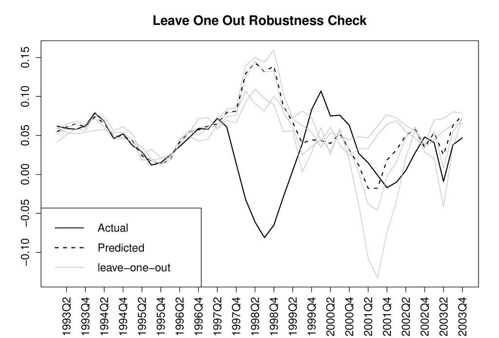

Figure 8: Leave-one-out robustness check.

If the user would prefer to reproduce the plot and manipulate the code to his or her liking, they should modify the following code, which replicates the above plot.

```r
> linewidth <- matrix(1, 1, ncol(rob.check))
> linewidth <- append(linewidth, c(2, 2), after = 0)
>
> matplot(c(time.pretr, time.tr), cbind(apt.table[, 1:2], rob.check),
+          type = "l", xlab = "", ylab = "GDP growth gap",
+          col = c(1, 1, matrix("gray", 1, ncol(rob.check))),
+          lty = c(1, 2, matrix(1, 1, ncol(rob.check))), lwd = linewidth, xaxt = "n")
> ## Axis
> axis(1, at = c(time.pretr, time.tr)[c(seq(4, length(c(time.pretr, time.tr)),
+      by = 4))], labels = c(rownames(growth)[c(time.pretr, time.tr)
+      [c(seq(4, length(c(time.pretr, time.tr)), by = 4))]]), las = 3)
> title(xlab = "Quarter", mgp = c(3.6, 0.5, 0))
> ## Legend
> legend("bottomleft", c("Hong Kong", "Predicted", "leave-one-out"),
+        col = c(1, 1, "gray"), lty = c(1, 2, 1), lwd = c(2, 2, 1))
> ## Vertical line when treatment begins
> abline(v = max(time.pretr), lty = 3, lwd = 2)
```

# Acknowledgments

I would like to thank Javier Gardeazabal and Yang Yang for their helpful comments and testing of the package, as well as the anonymous referees who suggested thoughtful improvements.

Funding for this research was provided by the Basque Government through grant EC-2013-1-53.

Abadie, A., A. Diamond, and J. Hainmueller. 2010. “Control Methods for Comparative Case Studies: Estimating the Effect of California’s Tobacco Control Program.” *Journal of the American Statistical Association* 105 (490): 493–505.

Abadie, Alberto, Alexis Diamond, and Jens Hainmueller. 2015. “Comparative Politics and the Synthetic Control Method.” *American Journal of Political Science* 59 (2): 495–510.

Abadie, Alberto, and Javier Gardeazabal. 2003. “The Economic Costs of Conflict: A Case Study of the Basque Country.” *American Economic Review* 93 (1): 113–32.

Dahl, David B. 2014. *Xtable: Export Tables to LaTeX or HTML*. https://CRAN.R-project.org/package=xtable.

Hsiao, Cheng, H. Steve Ching, and Shui Ki Wan. 2012. “A Panel Data Approach for Program Evaluation: Measuring the Benefits of Political and Economic Integration of Hong Kong with Mainland China.” *Journal of Applied Econometrics* 27 (5): 705–40. https://doi.org/10.1002/jae.1230.

Lumley, Thomas. 2014. *Leaps: Regression Subset Selection*. https://CRAN.R-project.org/package=leaps.

Rubin, Donald B. 1974. “Estimating Causal Effects of Treatments in Randomized and Nonrandomized Studies.” *Journal of Educational Psychology* 66 (5): 688–701.

[^1]: (Hsiao, Steve Ching, and Ki Wan 2012) conduct the analysis using both AIC and AICc criteria; in the implementation of the method in the *pampe* package both criteria plus BIC are included.
[^2]: $T_0-4$ is to allow for at least three degrees of freedom.
[^3]: The user will notice that these are not the same inference tests as the ones proposed by (Hsiao, Steve Ching, and Ki Wan 2012). The problem with those tests is that they cannot be carried out in a systematic way and therefore, they cannot be built into the package. However, the user can still choose to use the `pampe()` function without placebo tests and carry out the inference in such a way if they wish to do so, using the `acf()` and `arima()` functions from the base package *stats*.
[^4]: This might change in future versions.
[^5]: There is one last argument, `placebos`, that is not mentioned here but it will be discussed further in Section 3.3.
[^6]: If the `placebos` argument is not set to `FALSE` there are additional results, which will be explained in Section 3.3.